# Importing Data into R - Part 2

Lessons from DataCamp

# Introduction

The following documentoutlines the written portion of the lessons from [DataCamp](https://www.datacamp.com/)’s [Importing Data in R (Part 2)" course](https://www.datacamp.com/courses/importing-data-in-r-part-2). This is a follow-up to the “Importing Data in R (Part 1) That requires you to understand the basics of importing data.In this second part to Importing Data in R, you will take a deeper dive into the wide range of data formats out there. More specifically, you’ll learn how to import data from relational databases and how to import and work with data coming from the web. Finally, you’ll get hands-on experience with importing data from statistical software packages such SAS, STATA and SPSS.

As a note: All text is completely copied and pasted from the course. There are insances where the document refers to the “editor on the right”, please note, that in this notebook document all of the instances are noted in the “r-chunks” (areas containing working r-code), which occurs below the text, rather than to the right. Furthermore, This lesson contained instructional videos at the beginign of new concepts that are not detailed in this document. However, even without these videos, the instructions are quite clear in indicating what the code is accomplishing.

*If you have this document open on “R-Notebook”, simply click “run” -> “Run all” (Or just press ‘ctrl + alt + r’), let the “r-chunks” run (This might take a bit of time) then click “Preview”. All necessary data is embedded within the code, no need to set a working directory or open an R-project.*

This document was created by Neil Yetz on 10/01/2017. Please send any questions or concerns in this document to Neil at ndyetz@gmail.com

# Chapter 1: Importing data from databases (Part 1)

Many companies store their information in relational databases. The R community has also developed R packages to get data from these architectures. You’ll learn how to connect to a database and how to retrieve data from it.

## Establish a connection

The first step to import data from a SQL database is creating a connection to it. As Filip explained, you need different packages depending on the database you want to connect to. All of these packages do this in a uniform way, as specified in the `DBI` package.

`dbConnect()` creates a connection between your R session and a SQL database. The first argument has to be a `DBIdriver` object, that specifies how connections are made and how data is mapped between R and the database. Specifically for MySQL databases, you can build such a driver with `RMySQL::MySQL()`.

If the MySQL database is a remote database hosted on a server, you’ll also have to specify the following arguments in `dbConnect()`: `dbname`, `host`, `port`, `user` and `password`. Most of these details have already been provided.

**Instructions**

Load the `DBI` library, which is already installed on DataCamp’s servers. Edit the `dbConnect()` call to connect to the MySQL database. Change the port argument (`3306`) and user argument (`"student"`).

```r
# Load the DBI package
#install.packages("DBI")
library(DBI)
# Edit dbConnect() call
con <- dbConnect(RMySQL::MySQL(),
                 dbname = "tweater",
                 host = "courses.csrrinzqubik.us-east-1.rds.amazonaws.com",
                 port = 3306,
                 user = "student",
                 password = "datacamp")
```

## Inspect the connection

Now that you’ve successfully created the database connection, let’s have a closer look at it. With the object `con` available in your workspace, can you tell which of the following statements is true?

**Possible Answers** (Correct answer is **Bolded**)

`con` is an `SQLConnection` object.  
`con` is a `PostgreSQLConnection` object.  
**`con` is an `MySQLConnection` object.**  
`con` is an `NoSQLConnection` object.

## List the database tables

After you’ve successfully connected to a remote MySQL database, the next step is to see what tables the database contains. You can do this with the `dbListTables()` function. As you might remember from the video, this function requires the connection object as an input, and outputs a character vector with the table names.

**Instructions**

Add code to create a vector `tables`, that contains the tables in the tweater database. You can connect to this database through the `con` object.

Display the structure of `tables`; what’s the class of this vector?

```r
# Load the DBI package
library(DBI)
# Connect to the MySQL database: con
con <- dbConnect(RMySQL::MySQL(),
                 dbname = "tweater",
                 host = "courses.csrrinzqubik.us-east-1.rds.amazonaws.com",
                 port = 3306,
                 user = "student",
                 password = "datacamp")
# Build a vector of table names: tables
tables <- dbListTables(con)
# Display structure of tables
str(tables)
```

```
 chr [1:3] "comments" "tweats" "users"
```

## Import users

As you might have guessed by now, the database contains data on a more tasty version of Twitter, namely Tweater. Users can post tweats with short recipes for delicious snacks. People can comment on these tweats. There are three tables: **users**, **tweats**, and **comments** that have relations among them. Which ones, you ask? You’ll discover in a moment!

Let’s start by importing the data on the users into your R session. You do this with the `dbReadTable()` function. Simply pass it the connection object (`con`), followed by the name of the table you want to import. The resulting object is a standard R data frame.

**Instructions**

Add code that imports the `"users"` table from the tweater database and store the resulting data frame as `users`.

Print the `users` data frame.

```r
# Load the DBI package
library(DBI)
# Connect to the MySQL database: con
con <- dbConnect(RMySQL::MySQL(),
                 dbname = "tweater",
                 host = "courses.csrrinzqubik.us-east-1.rds.amazonaws.com",
                 port = 3306,
                 user = "student",
                 password = "datacamp")
# Import the users table from tweater: users
users <- dbReadTable(con, "users")
# Print users
print(users)
```

| id | name | login |
| --- | --- | --- |
| 1 | elisabeth | elismith |
| 2 | mike | mikey |
| 3 | thea | teatime |
| 4 | thomas | tomatotom |
| 5 | oliver | olivander |
| 6 | kate | katebenn |
| 7 | anjali | lianja |

## Import all tables

Next to the `users`, we’re also interested in the `tweats` and `comments` tables. However, separate `dbReadTable()` calls for each and every one of the tables in your database would mean a lot of code duplication. Remember about the `lapply()` function? You can use it again here! A connection is already coded for you, as well as a vector `table_names`, containing the names of all the tables in the database.

**Instructions**

Finish the `lapply()` function to import the `users`, `tweats` and `comments` tables in a single call. The result, a list of data frames, will be stored in the variable `tables`. Print `tables` to check if you got it right.

```r
# Load the DBI package
library(DBI)
# Connect to the MySQL database: con
con <- dbConnect(RMySQL::MySQL(),
                 dbname = "tweater",
                 host = "courses.csrrinzqubik.us-east-1.rds.amazonaws.com",
                 port = 3306,
                 user = "student",
                 password = "datacamp")
# Get table names
table_names <- dbListTables(con)
# Import all tables
tables <- lapply(table_names, dbReadTable, conn = con)
# Print out tables
tables
```

| id | tweat_id | user_id | message |
| --- | --- | --- | --- |
| 1022 | 87 | 7 | nice! |
| 1000 | 77 | 7 | great! |
| 1011 | 49 | 5 | love it |
| 1012 | 87 | 1 | awesome! thanks! |
| 1010 | 88 | 6 | yuck! |
| 1026 | 77 | 4 | not my thing! |
| 1004 | 49 | 1 | this is fabulous! |
| 1030 | 75 | 6 | so easy! |
| 1025 | 88 | 2 | oh yes |
| 1007 | 49 | 3 | serious? |

[output cut: 2 more lines]

| id | user_id | post | date |
| --- | --- | --- | --- |
| 75 | 3 | break egg. bake egg. eat egg. | 2015-09-05 |
| 88 | 4 | wash strawberries. add ice. blend. enjoy. | 2015-09-14 |
| 77 | 6 | 2 slices of bread. add cheese. grill. heaven. | 2015-09-21 |
| 87 | 5 | open and crush avocado. add shrimps. perfect starter. | 2015-09-22 |
| 49 | 1 | nachos. add tomato sauce, minced meat and cheese. oven for 10 mins. | 2015-09-22 |
| 24 | 7 | just eat an apple. simply and healthy. | 2015-09-24 |

| id | name | login |
| --- | --- | --- |
| 1 | elisabeth | elismith |
| 2 | mike | mikey |
| 3 | thea | teatime |
| 4 | thomas | tomatotom |
| 5 | oliver | olivander |
| 6 | kate | katebenn |
| 7 | anjali | lianja |

```
NA
```

## How do the tables relate?

The connection to the MySQL database `con` has already been created for you. `tables`, a list containing the three tables as data frames that you’ve created in the previous exercise, is also available.

If you have a closer look at these tables, you’ll see that the `tweats` table, for example, contains a column `user_id`. The ids in the column refer to the users that have posted the tweat. Similarly, the `comments` contain both a `user_id` and a `tweat_id` column. It specifies which user posted a comment on which tweat.

With this new knowledge, can you tell **who** posted the **tweat** on which somebody commented “awesome! thanks!” (comment 1012)?

# Chapter 2: Importing data from databases (Part 2)

Importing an entire table from a database while you might only need a tiny bit of information seems like a lot of unncessary work. In this chapter, you’ll learn about SQL queries, which will help you make things more efficient by performing some computations on the database side.

## SQL with R

### Query tweater(1)

In your life as a data scientist, you’ll often be working with huge databases that contain tables with millions of rows. If you want to do some analyses on this data, it’s possible that you only need a fraction of this data. In this case, it’s a good idea to send SQL queries to your database, and only import the data you actually need into R.

`dbGetQuery()` is what you need. As usual, you first pass the connection object to it. The second argument is an SQL query in the form of a character string. This example selects the `age` variable from the `people` dataset where `gender` equals `"male"`:

```
dbGetQuery(con, "SELECT age FROM people WHERE gender = 'male'")
```

A connection to the `tweater` database has already been coded for you.

**Instructions**

Use `dbGetQuery()` to create a data frame, `elisabeth`, that **selects** the `tweat_id` column **from** the `comments` table **where** elisabeth is the commenter, her `user_id` is 1

Print out `elisabeth` so you can see if you queried the database correctly.

```r
# Connect to the database
library(DBI)
con <- dbConnect(RMySQL::MySQL(),
                 dbname = "tweater",
                 host = "courses.csrrinzqubik.us-east-1.rds.amazonaws.com",
                 port = 3306,
                 user = "student",
                 password = "datacamp")
# Import tweat_id column of comments where user_id is 1: elisabeth
elisabeth <- dbGetQuery(con, "SELECT tweat_ID FROM comments WHERE user_id = 1")
# Print elisabeth
elisabeth
```

| tweat_ID |
| --- |
| 87 |
| 49 |
| 77 |
| 77 |

### Query tweater(2)

Apart from checking equality, you can also check for less than and greater than relationships, with `<` and `>`, just like in R.

`con`, a connection to the `tweater` database, is again available.

**Instructions**

Create a data frame, `latest`, that **selects** the `post` column **from** the `tweats` table observations **where** the `date` is higher than `'2015-09-21'`.

Print out `latest`.

```r
# Connect to the database
library(DBI)
con <- dbConnect(RMySQL::MySQL(),
                 dbname = "tweater",
                 host = "courses.csrrinzqubik.us-east-1.rds.amazonaws.com",
                 port = 3306,
                 user = "student",
                 password = "datacamp")
# Import post column of tweats where date is higher than '2015-09-21': latest
latest <- dbGetQuery(con, "SELECT post FROM tweats WHERE date > '2015-09-21'")
# Print latest
latest
```

| post |
| --- |
| open and crush avocado. add shrimps. perfect starter. |
| nachos. add tomato sauce, minced meat and cheese. oven for 10 mins. |
| just eat an apple. simply and healthy. |

### Query tweater(3)

Suppose that you have a `people` table, with a bunch of information. This time, you want to find out the `age` and `country` of married males. Provided that there is a `married` column that’s 1 when the person in question is married, the following query would work.

```
SELECT age, country
  FROM people
    WHERE gender = "male" AND married = 1
```

Can you use a similar approach for a more specialized query on the `tweater` database?

**Instructions**

Create an R data frame, `specific`, that selects the `message` column from the `comments` table where the tweat_id is 77 **and** the `user_id` is greater than 4.

Print `specific`.

```r
# Connect to the database
library(DBI)
con <- dbConnect(RMySQL::MySQL(),
                 dbname = "tweater",
                 host = "courses.csrrinzqubik.us-east-1.rds.amazonaws.com",
                 port = 3306,
                 user = "student",
                 password = "datacamp")
# Create data frame specific
specific <- dbGetQuery(con, 'SELECT message FROM comments WHERE tweat_id = 77 AND user_id > 4')
# Print specific
specific
```

| message |
| --- |
| great! |

### Query tweater(4)

There are also dedicated SQL functions that you can use in the `WHERE` clause of an SQL query. For example, `CHAR_LENGTH()` returns the number of characters in a string.

**Instructions**

Create a data frame, `short`, that selects the `id` and `name` columns from the `users` table where the number of characters in the `name` is strictly less than 5.

Print `short`.

```r
# Connect to the database
library(DBI)
con <- dbConnect(RMySQL::MySQL(),
                 dbname = "tweater",
                 host = "courses.csrrinzqubik.us-east-1.rds.amazonaws.com",
                 port = 3306,
                 user = "student",
                 password = "datacamp")
# Create data frame short
short <- dbGetQuery(con, "SELECT id, name FROM users WHERE CHAR_LENGTH(name) < 5")
# Print short
short
```

| id | name |
| --- | --- |
| 2 | mike |
| 3 | thea |
| 6 | kate |

## Join the query madness!

Of course, SQL does not stop with the the three keywords `SELECT`, `FROM` and `WHERE`. Another very often used keyword is `JOIN`, and more specifically `INNER JOIN`. Take this call for example:

```
SELECT name, post
  FROM users INNER JOIN tweats on users.id = user_id
    WHERE date > "2015-09-19"
```

Here, the `users` table is joined with the `tweats` table. This is possible because the `id` column in the `users` table corresponds to the `user_id` column in the `tweats` table. Also notice how `name`, from the `users` table, and `post` and `date`, from the `tweats` table, can be referenced to without problems.

Can you predict the outcome of the following query?

```
SELECT post, message
  FROM tweats INNER JOIN comments on tweats.id = tweat_id
    WHERE tweat_id = 77
```

A connection to the tweater database is already available as con; feel free to experiment!

**INSTRUCTIONS**

Possible Answers (COrrect Answer is **Bolded**)

Trying to get the results of this SQL query throws an error.

**A table with four observations, containing two columns: post and message.**

A table with six observations, containing all columns in the tweats table.

A table with six observations, containing the columns post and message.

## Send - Fetch - Clear

You’ve used `dbGetQuery()` multiple times now. This is a virtual function from the `DBI` package, but is actually implemented by the `RMySQL` package. Behind the scenes, the following steps are performed:

- Sending the specified query with `dbSendQuery()`;
- Fetching the result of executing the query on the database with `dbFetch()`;
- Clearing the result with `dbClearResult()`.

Let’s not use `dbGetQuery()` this time and implement the steps above. This is tedious to write, but it gives you the ability to fetch the query’s result in chunks rather than all at once. You can do this by specifying the n argument inside `dbFetch()`.

**INSTRUCTIONS**

Inspect the `dbSendQuery()` call that has already been coded for you. It selects the comments for the users with an id above 4.

Use `dbFetch()` twice. In the first call, import only two records of the query result by setting the `n` argument to 2. In the second call, import all remaining queries (don’t specify `n`). In both calls, simply print the resulting data frames.

Clear `res` with `dbClearResult()`.

```r
# Connect to the database
library(DBI)
con <- dbConnect(RMySQL::MySQL(),
                 dbname = "tweater",
                 host = "courses.csrrinzqubik.us-east-1.rds.amazonaws.com",
                 port = 3306,
                 user = "student",
                 password = "datacamp")
# Send query to the database
res <- dbSendQuery(con, "SELECT * FROM comments WHERE user_id > 4")
# Use dbFetch() twice
dbFetch(res, n=2)
```

| id | tweat_id | user_id | message |
| --- | --- | --- | --- |
| 1022 | 87 | 7 | nice! |
| 1000 | 77 | 7 | great! |

```r
dbFetch(res)
```

| id | tweat_id | user_id | message |
| --- | --- | --- | --- |
| 1011 | 49 | 5 | love it |
| 1010 | 88 | 6 | yuck! |
| 1030 | 75 | 6 | so easy! |

```r
# Clear res
dbClearResult(res)
```

```
[1] TRUE
```

## Be polite and …

Every time you connect to a database using `dbConnect()`, you’re creating a new connection to the database you’re referencing. `RMySQL` automatically specifies a maximum of open connections and closes some of the connections for you, but still: it’s always polite to manually disconnect from the database afterwards. You do this with the `dbDisconnect()` function.

The code that connects you to the database is already available, can you finish the script?

**INSTRUCTIONS**

Using the technique you prefer, build a data frame `long_tweats`. It selects the `post` and `date` columns from the observations in `tweats` where the character length of the `post` variable exceeds `40`.

Print `long_tweats`.

Disconnect from the database by using `dbDisconnect()`.

```r
# Load RMySQL package
library(DBI)
# Connect to the database
library(DBI)
con <- dbConnect(RMySQL::MySQL(),
                 dbname = "tweater",
                 host = "courses.csrrinzqubik.us-east-1.rds.amazonaws.com",
                 port = 3306,
                 user = "student",
                 password = "datacamp")
# Create the data frame  long_tweats
long_tweats <- dbGetQuery(con, "SELECT post, date FROM tweats WHERE CHAR_LENGTH(post) > 40")
# Print long_tweats
print(long_tweats)
```

| post | date |
| --- | --- |
| wash strawberries. add ice. blend. enjoy. | 2015-09-14 |
| 2 slices of bread. add cheese. grill. heaven. | 2015-09-21 |
| open and crush avocado. add shrimps. perfect starter. | 2015-09-22 |
| nachos. add tomato sauce, minced meat and cheese. oven for 10 mins. | 2015-09-22 |

```r
# Disconnect from the database
dbDisconnect(con)
```

```
[1] TRUE
```

# Chapter 3: Importing data from the web (Part 1)

More and more of the information that data scientists are using resides on the web. Importing this data into R requires an understanding of the protocols used on the web. In this chapter, you’ll get a crash course in HTTP and learn to perform your own HTTP requests from inside R.

## Import flat files from the web

In the video, you saw that the `utils` functions to import flat file data, such as `read.csv()` and `read.delim()`, are capable of automatically importing from URLs that point to flat files on the web.

You must be wondering whether Hadley Wickham’s alternative package, `readr`, is equally potent. Well, figure it out in this exercise! The URLs for both a `.csv` file as well as a `.delim` file are already coded for you. It’s up to you to actually import the data. If it works, that is…

**INSTRUCTIONS**

Load the `readr` package. It’s already installed on DataCamp’s servers.

Use `url_csv` to read in the `.csv` file it is pointing to. Use the `read_csv()` function. The `.csv` contains column names in the first row. Save the resulting data frame as `pools`.

Similarly, use `url_delim` to read in the online `.txt` file. Use the `read_tsv()` function and store the result as potatoes.

Print `pools` and `potatoes`. Looks correct?

```r
# Load the readr package
library(readr)
# Import the csv file: pools
url_csv <- "http://s3.amazonaws.com/assets.datacamp.com/production/course_1478/datasets/swimming_pools.csv"
pools <- read_csv(url_csv, col_names = TRUE)
# Import the txt file: potatoes
url_delim <- "http://s3.amazonaws.com/assets.datacamp.com/production/course_1478/datasets/potatoes.txt"
potatoes <- read_tsv(url_delim, col_names = TRUE)
# Print pools and potatoes
pools
```

| Name | Address | Latitude | Longitude |
| --- | --- | --- | --- |
| Acacia Ridge Leisure Centre | 1391 Beaudesert Road, Acacia Ridge | -27.58616 | 153.0264 |
| Bellbowrie Pool | Sugarwood Street, Bellbowrie | -27.56547 | 152.8911 |
| Carole Park | Cnr Boundary Road and Waterford Road Wacol | -27.60744 | 152.9315 |
| Centenary Pool (inner City) | 400 Gregory Terrace, Spring Hill | -27.45537 | 153.0251 |
| Chermside Pool | 375 Hamilton Road, Chermside | -27.38583 | 153.0351 |
| Colmslie Pool (Morningside) | 400 Lytton Road, Morningside | -27.45516 | 153.0789 |
| Spring Hill Baths (inner City) | 14 Torrington Street, Springhill | -27.45960 | 153.0215 |
| Dunlop Park Pool (Corinda) | 794 Oxley Road, Corinda | -27.54652 | 152.9806 |
| Fortitude Valley Pool | 432 Wickham Street, Fortitude Valley | -27.45390 | 153.0368 |
| Hibiscus Sports Complex (upper MtGravatt) | 90 Klumpp Road, Upper Mount Gravatt | -27.55183 | 153.0735 |

[output cut: 10 more lines]

```r
potatoes
```

| area | temp | size | storage | method | texture | flavor | moistness |
| --- | --- | --- | --- | --- | --- | --- | --- |
| 1 | 1 | 1 | 1 | 1 | 2.9 | 3.2 | 3.0 |
| 1 | 1 | 1 | 1 | 2 | 2.3 | 2.5 | 2.6 |
| 1 | 1 | 1 | 1 | 3 | 2.5 | 2.8 | 2.8 |
| 1 | 1 | 1 | 1 | 4 | 2.1 | 2.9 | 2.4 |
| 1 | 1 | 1 | 1 | 5 | 1.9 | 2.8 | 2.2 |
| 1 | 1 | 1 | 2 | 1 | 1.8 | 3.0 | 1.7 |
| 1 | 1 | 1 | 2 | 2 | 2.6 | 3.1 | 2.4 |
| 1 | 1 | 1 | 2 | 3 | 3.0 | 3.0 | 2.9 |
| 1 | 1 | 1 | 2 | 4 | 2.2 | 3.2 | 2.5 |
| 1 | 1 | 1 | 2 | 5 | 2.0 | 2.8 | 1.9 |

[output cut: 150 more lines]

## Secure importing

In the previous exercises, you have been working with URLs that all start with `http://`. There is, however, a safer alternative to HTTP, namely HTTPS, which stands for HypterText Transfer Protocol Secure. Just remember this: HTTPS is relatively safe, HTTP is not.

Luckily for us, you can use the standard importing functions with `https://` connections since R version 3.2.2.

**INSTRUCTIONS**

Take a look at the URL in `url_csv`. It uses a secure connection, `https://`.

Use `read.csv()` to import the file at `url_csv`. The `.csv` file it is referring to contains column names in the first row. Call it `pools1`.

Load the `readr` package. It’s already installed on DataCamp’s servers.

Use `read_csv()` to read in the same `.csv` file in `url_csv`. Call it `pools2`.

Print out the structure of `pools1` and `pools2`. Looks like the importing went equally well as with a normal `http` connection!

```r
# https URL to the swimming_pools csv file.
url_csv <- "https://s3.amazonaws.com/assets.datacamp.com/production/course_1478/datasets/swimming_pools.csv"
# Import the file using read.csv(): pools1
pools1 <- read.csv(url_csv, header = TRUE)
# Load the readr package
library(readr)
# Import the file using read_csv(): pools2
pools2 <- read_csv(url_csv, col_names = TRUE)
# Print the structure of pools1 and pools2
str(pools1)
```

```
'data.frame':   20 obs. of  4 variables:
 $ Name     : Factor w/ 20 levels "Acacia Ridge Leisure Centre",..: 1 2 3 4 5 6 19 7 8 9 ...
 $ Address  : Factor w/ 20 levels "1 Fairlead Crescent, Manly",..: 5 20 18 10 9 11 6 15 12 17 ...
 $ Latitude : num  -27.6 -27.6 -27.6 -27.5 -27.4 ...
 $ Longitude: num  153 153 153 153 153 ...
```

```r
str(pools2)
```

```
Classes tbl_df, tbl and 'data.frame':   20 obs. of  4 variables:
 $ Name     : chr  "Acacia Ridge Leisure Centre" "Bellbowrie Pool" "Carole Park" "Centenary Pool (inner City)" ...
 $ Address  : chr  "1391 Beaudesert Road, Acacia Ridge" "Sugarwood Street, Bellbowrie" "Cnr Boundary Road and Waterford Road Wacol" "400 Gregory Terrace, Spring Hill" ...
 $ Latitude : num  -27.6 -27.6 -27.6 -27.5 -27.4 ...
 $ Longitude: num  153 153 153 153 153 ...
 - attr(*, "spec")=List of 2
  ..$ cols   :List of 4
  .. ..$ Name     : list()
  .. .. ..- attr(*, "class")= chr  "collector_character" "collector"
  .. ..$ Address  : list()
  .. .. ..- attr(*, "class")= chr  "collector_character" "collector"
  .. ..$ Latitude : list()
  .. .. ..- attr(*, "class")= chr  "collector_double" "collector"
  .. ..$ Longitude: list()
  .. .. ..- attr(*, "class")= chr  "collector_double" "collector"
  ..$ default: list()
  .. ..- attr(*, "class")= chr  "collector_guess" "collector"
  ..- attr(*, "class")= chr "col_spec"
```

## Import Excel files from the web

When you learned about `gdata`, it was already mentioned that `gdata` can handle `.xls` files that are on the internet. `readxl` can’t, at least not yet. The URL with which you’ll be working is already available in the sample code. You will import it once using `gdata` and once with the `readxl` package via a workaround.

**INSTRUCTIONS**

Load the `readxl` and `gdata` packages. They are already installed on DataCamp’s servers.

Import the `.xls` file located at the URL `url_xls` using `read.xls()` from `gdata`. Store the resulting data frame as `excel_gdata`.

You can not use `read_excel()` directly with a URL. Complete the following instructions to work around this problem:

Use `download.file()` to download the `.xls` file behind the URL and store it locally as `"local_latitude.xls"`.

Call `read_excel()` to import the local file, `"local_latitude.xls"`. Name the resulting data frame `excel_readxl`.

```r
# Load the readxl and gdata package
library(readxl)
library(gdata)


# Specification of url: url_xls
url_xls <- "http://s3.amazonaws.com/assets.datacamp.com/production/course_1478/datasets/latitude.xls"

# Import the .xls file with gdata: excel_gdata
excel_gdata <- read.xls(url_xls)

# Download file behind URL, name it local_latitude.xls
download.file(url_xls, "local_latitude.xls")

# Import the local .xls file with readxl: excel_readxl
excel_readxl <- read_excel("local_latitude.xls")
```

## Downloading any file, secure or not

In the previous exercise you’ve seen how you can read excel files on the web using the `read_excel` package by first downloading the file with the `download.file()` function.

There’s more: with `download.file()` you can download any kind of file from the web, using HTTP and HTTPS: images, executable files, but also `.RData` files. An `RData` file is very efficient format to store R data.

You can load data from an `RData` file using the `load()` function, but this function does not accept a URL string as an argument. In this exercise, you’ll first download the `RData` file securely, and then import the local data file.

**INSTRUCTIONS**

Take a look at the URL in `url_rdata`. It uses a secure connection, `https://`. This URL points to an `RData` file containing a data frame with some metrics on different kinds of wine.

Download the file at `url_rdata` using `download.file()`. Call the file `"wine_local.RData"` in your working directory.

Load the file you created, `wine_local.RData`, using the `load()` function. It takes one argument, the path to the file, which is just the filename in our case. After running this command, the variable `wine` will automatically be available in your workspace.

## Reading a text file from the web

Wow, you’ve learned a lot of ways to import a data file from the web in the previous exercises. Let’s see if you can remember what’s possible and what’s not.

Which way of importing data is *NOT* possible?

**INSTRUCTIONS** Possible Answers (cORRECT ANSWER IS **BOLDED**)

Importing a .csv file residing on the web using the URL with read.csv():

```
read.csv("http://s3.amazonaws.com/assets.datacamp.com/production/course_1478/datasets/swimming_pools.csv")
```

Downloading a remote excel and saving it to your working directory using download.file():

```
download.file("http://s3.amazonaws.com/assets.datacamp.com/production/course_1478/datasets/latitude.xlsx", "lat.xlsx")
```

Importing a .txt file residing on the web using the URL with read_tsv():

```
read_tsv("http://s3.amazonaws.com/assets.datacamp.com/production/course_1478/datasets/potatoes.txt")
```

**Using the load() function to load a remote RData file into the workspace with only the URL string:**

[output not shown]

## HTTP? httr! (1)

Downloading a file from the Internet means sending a GET request and receiving the file you asked for. Internally, all the previously discussed functions use a GET request to download files.

`httr` provides a convenient function, `GET()` to execute this GET request. The result is a `response` object, that provides easy access to the status code, content-type and, of course, the actual content.

You can extract the content from the request using the `content()` function. At the time of writing, there are three ways to retrieve this content: as a raw object, as a character vector, or an R object, such as a list. If you don’t tell `content()` how to retrieve the content through the `as` argument, it’ll try its best to figure out which type is most appropriate based on the content-type.

**INSTRUCTIONS**

Load the `httr` package. It’s already installed on DataCamp’s servers. Use `GET()` to get the URL stored in `url`. Store the result of this `GET()` call as `resp`.

Print the `resp` object. What information does it contain?

Get the content of `resp` using `content()` and set the `as` argument to `"raw"`. Assign the resulting vector to `raw_content`.

Print the first values in `raw_content` with `head()`.

```r
# Load the httr package
library(httr)
# Get the url, save response to resp
url <- "http://www.example.com/"
resp <- GET(url)
# Print resp
print(resp)
```

```
Response [http://www.example.com/]
  Date: 2018-03-10 03:11
  Status: 200
  Content-Type: text/html
  Size: 1.27 kB
<!doctype html>
<html>
<head>
    <title>Example Domain</title>

    <meta charset="utf-8" />
    <meta http-equiv="Content-type" content="text/html; charset=u...
    <meta name="viewport" content="width=device-width, initial-sc...
    <style type="text/css">
    body {
...
```

```r
# Get the raw content of resp: raw_content
raw_content <- content(resp, as = "raw")
# Print the head of raw_content
print(raw_content)
```

```
   [1] 3c 21 64 6f 63 74 79 70 65 20 68 74 6d 6c 3e 0a 3c 68 74 6d
  [21] 6c 3e 0a 3c 68 65 61 64 3e 0a 20 20 20 20 3c 74 69 74 6c 65
  [41] 3e 45 78 61 6d 70 6c 65 20 44 6f 6d 61 69 6e 3c 2f 74 69 74
  [61] 6c 65 3e 0a 0a 20 20 20 20 3c 6d 65 74 61 20 63 68 61 72 73
  [81] 65 74 3d 22 75 74 66 2d 38 22 20 2f 3e 0a 20 20 20 20 3c 6d
 [101] 65 74 61 20 68 74 74 70 2d 65 71 75 69 76 3d 22 43 6f 6e 74
 [121] 65 6e 74 2d 74 79 70 65 22 20 63 6f 6e 74 65 6e 74 3d 22 74
 [141] 65 78 74 2f 68 74 6d 6c 3b 20 63 68 61 72 73 65 74 3d 75 74
 [161] 66 2d 38 22 20 2f 3e 0a 20 20 20 20 3c 6d 65 74 61 20 6e 61
 [181] 6d 65 3d 22 76 69 65 77 70 6f 72 74 22 20 63 6f 6e 74 65 6e
 [201] 74 3d 22 77 69 64 74 68 3d 64 65 76 69 63 65 2d 77 69 64 74
 [221] 68 2c 20 69 6e 69 74 69 61 6c 2d 73 63 61 6c 65 3d 31 22 20
 [241] 2f 3e 0a 20 20 20 20 3c 73 74 79 6c 65 20 74 79 70 65 3d 22
 [261] 74 65 78 74 2f 63 73 73 22 3e 0a 20 20 20 20 62 6f 64 79 20
 [281] 7b 0a 20 20 20 20 20 20 20 20 62 61 63 6b 67 72 6f 75 6e 64
```

[output cut: 36 more lines]

## HTTP? httr! (2)

Web content does not limit itself to HTML pages and files stored on remote servers such as DataCamp’s Amazon S3 instances. There are many other data formats out there. A very common one is JSON. This format is very often used by so-called Web APIs, interfaces to web servers with which you as a client can communicate to get or store information in more complicated ways.

You’ll learn about Web APIs and JSON in the video and exercises that follow, but some experimentation never hurts, does it?

**INSTRUCTIONS**

Use `GET()` to get the `url` that has already been specified in the sample code. Store the response as `resp`.

Print `resp`. What is the content-type?

Use `content()` to get the content of `resp`. Set the `as` argument to `"text"`. Simply print out the result. What do you see?

Use `content()` to get the content of `resp`, but this time do not specify a second argument. R figures out automatically that you’re dealing with a JSON, and converts the JSON to a named R list.

```r
### httr is already loaded
# Get the url
url <- "http://www.omdbapi.com/?apikey=ff21610b&t=Annie+Hall&y=&plot=short&r=json"
resp <- GET(url)
# Print resp
print(resp)
```

```
Response [http://www.omdbapi.com/?apikey=ff21610b&t=Annie+Hall&y=&plot=short&r=json]
  Date: 2018-03-10 03:15
  Status: 200
  Content-Type: application/json; charset=utf-8
  Size: 942 B
```

```r
# Print content of resp as text
content(resp, as = "text")
```

```
[1] "{\"Title\":\"Annie Hall\",\"Year\":\"1977\",\"Rated\":\"PG\",\"Released\":\"20 Apr 1977\",\"Runtime\":\"93 min\",\"Genre\":\"Comedy, Romance\",\"Director\":\"Woody Allen\",\"Writer\":\"Woody Allen, Marshall Brickman\",\"Actors\":\"Woody Allen, Diane Keaton, Tony Roberts, Carol Kane\",\"Plot\":\…
```

```r
# Print content of resp
content(resp)
```

```
$Title
[1] "Annie Hall"

$Year
[1] "1977"

$Rated
[1] "PG"

$Released
[1] "20 Apr 1977"

$Runtime
[1] "93 min"

$Genre
[1] "Comedy, Romance"

$Director
[1] "Woody Allen"

$Writer
[1] "Woody Allen, Marshall Brickman"

$Actors
[1] "Woody Allen, Diane Keaton, Tony Roberts, Carol Kane"

$Plot
[1] "Neurotic New York comedian Alvy Singer falls in love with the ditzy Annie Hall."

$Language
[1] "English, German"

$Country
[1] "USA"

$Awards
[1] "Won 4 Oscars. Another 26 wins & 8 nominations."

$Poster
```

[output cut: 42 more lines]

```

$DVD
[1] "28 Apr 1998"

$BoxOffice
[1] "N/A"

$Production
[1] "United Artists"

$Website
[1] "N/A"

$Response
[1] "True"
```

# Chapter 4: Importing data from the web (Part 2)

Importing data from the web is one thing; actually being able to extract useful information is another. Learn more about the JSON format to get one step closer to web domination.

## From JSON to R

In the simplest setting, `fromJSON()` can convert character strings that represent JSON data into a nicely structured R list. Give it a try!

**INSTRUCTIONS**

Load the `jsonlite` package. It’s already installed on DataCamp’s servers.

`wine_json` represents a JSON. Use `fromJSON()` to convert it to a list, named `wine`.

Display the structure of `wine`

```r
# Load the jsonlite package
library(jsonlite)
# wine_json is a JSON
wine_json <- '{"name":"Chateau Migraine", "year":1997, "alcohol_pct":12.4, "color":"red", "awarded":false}'
# Convert wine_json into a list: wine
wine <- fromJSON(wine_json)
# Print structure of wine
str(wine)
```

```
List of 5
 $ name       : chr "Chateau Migraine"
 $ year       : int 1997
 $ alcohol_pct: num 12.4
 $ color      : chr "red"
 $ awarded    : logi FALSE
```

## Quandl API

As Filip showed in the video, `fromJSON()` also works if you pass a URL as a character string or the path to a local file that contains JSON data. Let’s try this out on the Quandl API, where you can fetch all sorts of financial and economical data.

**INSTRUCTIONS**

`quandl_url` represents a URL. Use `fromJSON()` directly on this URL and store the result in `quandl_data`.

Display the structure of `quandl_data`.

```r
# jsonlite is preloaded
# Definition of quandl_url
quandl_url <- "https://www.quandl.com/api/v3/datasets/WIKI/FB/data.json?auth_token=i83asDsiWUUyfoypkgMz"
# Import Quandl data: quandl_data
quandl_data <- fromJSON(quandl_url)
# Print structure of quandl_data
str(quandl_data)
```

```
List of 1
 $ dataset_data:List of 10
  ..$ limit       : NULL
  ..$ transform   : NULL
  ..$ column_index: NULL
  ..$ column_names: chr [1:13] "Date" "Open" "High" "Low" ...
  ..$ start_date  : chr "2012-05-18"
  ..$ end_date    : chr "2018-03-09"
  ..$ frequency   : chr "daily"
  ..$ data        : chr [1:1460, 1:13] "2018-03-09" "2018-03-08" "2018-03-07" "2018-03-06" ...
  ..$ collapse    : NULL
  ..$ order       : NULL
```

## OMDb API

In the video, you saw how easy it is to interact with an API once you know how to formulate requests. You also saw how to fetch all information on Rain Man from OMDb. Simply perform a `GET()` call, and next ask for the contents with the `content()` function. This `content()` function, which is part of the httr package, uses `jsonlite` behind the scenes to import the JSON data into R.

However, by now you also know that `jsonlite` can handle URLs itself. Simply passing the request URL to `fromJSON()` will get your data into R. In this exercise, you will be using this technique to compare the release year of two movies in the Open Movie Database.

**INSTRUCTIONS**

Two URLs are included in the sample code, as well as a `fromJSON()` call to build `sw4`. Add a similar call to build `sw3`.

Print out the element named `Title` of both `sw4` and `sw3`. You can use the `$` operator. What movies are we dealing with here?

Write an expression that evaluates to `TRUE` if `sw4` was released later than `sw3`. This information is stored in the `Year` element of the named lists.

```r
# The package jsonlite is already loaded
# Definition of the URLs
url_sw4 <- "http://www.omdbapi.com/?apikey=ff21610b&i=tt0076759&r=json"
url_sw3 <- "http://www.omdbapi.com/?apikey=ff21610b&i=tt0121766&r=json"
# Import two URLs with fromJSON(): sw4 and sw3
sw4 <- fromJSON(url_sw4)
sw3 <- fromJSON(url_sw3)
# Print out the Title element of both lists
print(sw4$Title)
```

```
[1] "Star Wars: Episode IV - A New Hope"
```

```r
print(sw3$Title)
```

```
[1] "Star Wars: Episode III - Revenge of the Sith"
```

```r
# Is the release year of sw4 later than sw3?
sw4$Year > sw3$Year
```

```
[1] FALSE
```

## JSON practice (1)

JSON is built on two structures: objects and arrays. To help you experiment with these, two JSON strings are included in the sample code. It’s up to you to change them appropriately and then call `jsonlite`’s `fromJSON()` function on them each time.

**INSTRUCTIONS**

Change the assignment of `json1` such that the R vector after conversion contains the numbers 1 up to 6, in ascending order. Next, call `fromJSON()` on `json1`.

Adapt the code for `json2` such that it’s converted to a named list with two elements: `a`, containing the numbers 1, 2 and 3 and `b`, containing the numbers 4, 5 and 6. Next, call fromJSON() on json2.

```r
# jsonlite is already loaded
# Challenge 1
json1 <- '[1, 2, 3, 4, 5, 6]'
fromJSON(json1)
```

```
[1] 1 2 3 4 5 6
```

```r
# Challenge 2
json2 <- '{"a": [1, 2, 3], "b": [4, 5, 6]}'
fromJSON(json2)
```

```
$a
[1] 1 2 3

$b
[1] 4 5 6
```

## JSON practice (2)

We prepared two more JSON strings in the sample code. Can you change them and call `jsonlite`’s `fromJSON()` function on them, similar to the previous exercise?

**INSTRUCTIONS**

Remove characters from `json1` to build a 2 by 2 matrix containing only 1, 2, 3 and 4. Call `fromJSON()` on `json1`.

Add characters to `json2` such that the data frame in which the json is converted contains an additional observation in the last row. For this observations, `a` equals 5 and `b` equals 6. Call `fromJSON()` one last time, on `json2`.

```r
# jsonlite is already loaded
# Challenge 1
json1 <- '[[1, 2], [3, 4]]'
fromJSON(json1)
```

```
     [,1] [,2]
[1,]    1    2
[2,]    3    4
```

```r
# Challenge 2
json2 <- '[{"a": 1, "b": 2}, {"a": 3, "b": 4}, {"a": 5, "b": 6} ]'
fromJSON(json2)
```

|  | a | b |
| --- | --- | --- |
| 1 | 1 | 2 |
| 2 | 3 | 4 |
| 3 | 5 | 6 |

## toJSON()

Apart from converting JSON to R with `fromJSON()`, you can also use `toJSON()` to convert R data to a JSON format. In its most basic use, you simply pass this function an R object to convert to a JSON. The result is an R object of the class `json`, which is basically a character string representing that JSON.

For this exercise, you will be working with a `.csv` file containing information on the amount of desalinated water that is produced around the world. As you’ll see, it contains a lot of missing values. This data can be found on the URL that is specified in the sample code.

**INSTRUCTIONS**

Use a function of the `utils` package to import the `.csv` file directly from the URL specified in `url_csv`. Save the resulting data frame as `water`. Make sure that strings are not imported as factors.

Convert the data frame water to a JSON. Call the resulting object `water_json`.

Print out `water_json`.

```r
# jsonlite is already loaded
# URL pointing to the .csv file
url_csv <- "http://s3.amazonaws.com/assets.datacamp.com/production/course_1478/datasets/water.csv"
# Import the .csv file located at url_csv
water <- read.csv(url_csv, stringsAsFactors = FALSE)
# Convert the data file according to the requirements
water_json <- toJSON(water)
# Print out water_json
print(water_json)
```

```
[{"water":"Algeria","X1992":0.064,"X2002":0.017},{"water":"American Samoa"},{"water":"Angola","X1992":0.0001,"X2002":0.0001},{"water":"Antigua and Barbuda","X1992":0.0033},{"water":"Argentina","X1992":0.0007,"X1997":0.0007,"X2002":0.0007},{"water":"Australia","X1992":0.0298,"X2002":0.0298},{"water":…
```

## Minify and prettify

JSONs can come in different formats. Take these two JSONs, that are in fact exactly the same: the first one is in a minified format, the second one is in a pretty format with indentation, whitespace and new lines:

```
# Mini
{"a":1,"b":2,"c":{"x":5,"y":6}}

# Pretty
{
  "a": 1,
  "b": 2,
  "c": {
    "x": 5,
    "y": 6
  }
}
```

Unless you’re a computer, you surely prefer the second version. However, the standard form that `toJSON()` returns, is the minified version, as it is more concise. You can adapt this behavior by setting the `pretty` argument inside `toJSON()` to `TRUE`. If you already have a JSON string, you can use `prettify()` or `minify()` to make the JSON pretty or as concise as possible.

**INSTRUCTIONS**

Convert the `mtcars` dataset, which is available in R by default, to a pretty `JSON`. Call the resulting JSON `pretty_json`.

Print out `pretty_json`. Can you understand the output easily?

Convert `pretty_json` to a minimal version using `minify()`. Store this version under a new variable, `mini_json`.

Print out `mini_json`. Which version do you prefer, the pretty one or the minified one?

```r
# jsonlite is already loaded

# Convert mtcars to a pretty JSON: pretty_json
pretty_json <- toJSON(mtcars, pretty = TRUE)

# Print pretty_json
print(pretty_json)

# Minify pretty_json: mini_json
mini_json <- minify(pretty_json)

# Print mini_json
print(mini_json)
```

[output not shown]

# Chapter 5: Importing data from statistical software packages

Next to R, there are also other commonly used statistical software packages: SAS, STATA and SPSS. Each of them has their own file format. Learn how to use the haven and foreign packages to get them into R with remarkable ease!

## Import SAS data with haven

`haven` is an extremely easy-to-use package to import data from three software packages: SAS, STATA and SPSS. Depending on the software, you use different functions:

SAS: read_sas()

STATA: read_dta() (or read_stata(), which are identical)

SPSS: read_sav() or read_por(), depending on the file type.

All these functions take one key argument: the path to your local file. In fact, you can even pass a URL; `haven` will then automatically download the file for you before importing it.

**INSTRUCTIONS**

Load the `haven` package; it’s already installed on DataCamp’s servers. Import the data file “sales.sas7bdat”. Call the imported data frame sales.

Display the structure of `sales` with `str()`. Some columns represent categorical variables, so they should be factors.

```r
# Load the haven package
library(haven)
# Import sales.sas7bdat: sales
sales <- read_sas("sales.sas7bdat")
# Display the structure of sales
str(sales)
```

```
Classes tbl_df, tbl and 'data.frame':   431 obs. of  4 variables:
 $ purchase: num  0 0 1 1 0 0 0 0 0 0 ...
 $ age     : num  41 47 41 39 32 32 33 45 43 40 ...
 $ gender  : chr  "Female" "Female" "Female" "Female" ...
 $ income  : chr  "Low" "Low" "Low" "Low" ...
 - attr(*, "label")= chr "SALES"
```

## Import STATA data with haven

Next up are STATA data files; you can use `read_dta()` for these.

When inspecting the result of the `read_dta()` call, you will notice that one column will be imported as a `labelled` vector, an R equivalent for the common data structure in other statistical environments. In order to effectively continue working on the data in R, it’s best to change this data into a standard R class. To convert a variable of the class `labelled` to a factor, you’ll need haven’s `as_factor()` function.

In this exercise, you will work with data on yearly import and export numbers of sugar, both in USD and in weight. The data can be found at: http://assets.datacamp.com/production/course_1478/datasets/trade.dta

**INSTRUCTIONS**

Import the data file directly from the URL using `read_dta()`, and store it as `sugar`.

Print out the structure of `sugar`. The `Date` column has class `labelled`.

Convert the values in the `Date` column of `sugar` to dates, using `as.Date(as_factor(___))`.

Print out the structure of `sugar` once more. Looks better now?

```r
# haven is already loaded
# Import the data from the URL: sugar
sugar <- read_dta("http://assets.datacamp.com/production/course_1478/datasets/trade.dta")
# Structure of sugar
str(sugar)
```

```
Classes tbl_df, tbl and 'data.frame':   10 obs. of  5 variables:
 $ Date    :Class 'labelled'  atomic [1:10] 10 9 8 7 6 5 4 3 2 1
  .. ..- attr(*, "label")= chr "Date"
  .. ..- attr(*, "format.stata")= chr "%9.0g"
  .. ..- attr(*, "labels")= Named num [1:10] 1 2 3 4 5 6 7 8 9 10
  .. .. ..- attr(*, "names")= chr [1:10] "2004-12-31" "2005-12-31" "2006-12-31" "2007-12-31" ...
 $ Import  : atomic  37664782 16316512 11082246 35677943 9879878 ...
  ..- attr(*, "label")= chr "Import"
  ..- attr(*, "format.stata")= chr "%9.0g"
 $ Weight_I: atomic  54029106 21584365 14526089 55034932 14806865 ...
  ..- attr(*, "label")= chr "Weight_I"
  ..- attr(*, "format.stata")= chr "%9.0g"
 $ Export  : atomic  5.45e+07 1.03e+08 3.79e+07 4.85e+07 7.15e+07 ...
  ..- attr(*, "label")= chr "Export"
  ..- attr(*, "format.stata")= chr "%9.0g"
 $ Weight_E: atomic  9.34e+07 1.58e+08 8.80e+07 1.12e+08 1.32e+08 ...
  ..- attr(*, "label")= chr "Weight_E"
  ..- attr(*, "format.stata")= chr "%9.0g"
 - attr(*, "label")= chr "Written by R."
```

```r
# Convert values in Date column to dates
sugar$Date <- as.Date(as_factor(sugar$Date))
# Structure of sugar again
str(sugar)
```

```
Classes tbl_df, tbl and 'data.frame':   10 obs. of  5 variables:
 $ Date    : Date, format: "2013-12-31" ...
 $ Import  : atomic  37664782 16316512 11082246 35677943 9879878 ...
  ..- attr(*, "label")= chr "Import"
  ..- attr(*, "format.stata")= chr "%9.0g"
 $ Weight_I: atomic  54029106 21584365 14526089 55034932 14806865 ...
  ..- attr(*, "label")= chr "Weight_I"
  ..- attr(*, "format.stata")= chr "%9.0g"
 $ Export  : atomic  5.45e+07 1.03e+08 3.79e+07 4.85e+07 7.15e+07 ...
  ..- attr(*, "label")= chr "Export"
  ..- attr(*, "format.stata")= chr "%9.0g"
 $ Weight_E: atomic  9.34e+07 1.58e+08 8.80e+07 1.12e+08 1.32e+08 ...
  ..- attr(*, "label")= chr "Weight_E"
  ..- attr(*, "format.stata")= chr "%9.0g"
 - attr(*, "label")= chr "Written by R."
```

## What does the graphic tell?

A plot can be very useful to explore the relationship between two variables. If you pass the `plot()` function two arguments, the first one will be plotted on the x-axis, the second one will be plotted on the y-axis.

The sugar trading data is again available at http://assets.datacamp.com/production/course_1478/datasets/trade.dta.

After you’ve imported the data frame, you should plot two of its variables, `Import` against `Weight_I`, and describe their relationship! `haven` is already loaded in your R session, so you can start importing straight away.

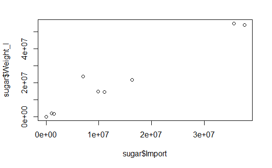

```r
sugar <- read_dta("http://assets.datacamp.com/production/course_1478/datasets/trade.dta")
plot(sugar$Import, sugar$Weight_I)
```

**INSTRUCTIONS**

Possible Answers (Correct Answer is **Bolded**)

The relation between the import figures in USD and the import figures in weight can be described with a quadratic function that has a local maximum.

**The import figures in USD and the import figures in weight are rather positively correlated.**

The import figures in USD and the import figures in weight are negatively associated. Along the points there is a monotonic decreasing trend.

No relationship can be guessed between the weight and the value of the imported sugar.

## Import SPSS data with haven

The `haven` package can also import data files from SPSS. Again, importing the data is pretty straightforward. Depending on the SPSS data file you’re working with, you’ll need either `read_sav()` - for `.sav` files - or `read_por()` - for `.por` files.

In this exercise, you will work with data on four of the Big Five personality traits for 434 persons (Source: University of Bath). The Big Five is a psychological concept including, originally, five dimensions of personality to classify human personality. The SPSS dataset is called `person.sav` and is available in your working directory.

**INSTRUCTIONS**

Use `read_sav()` to import the SPSS data in `"person.sav"`. Name the imported data frame `traits`.

`traits` contains several missing values, or `NAs`. Run `summary()` on it to find out how many `NA`s are contained in each variable.

Print out a subset of those individuals that scored high on Extroversion and on Agreeableness, i.e. scoring higher than 40 on each of these two categories. You can use `subset()` for this.

```r
# haven is already loaded
# Import person.sav: traits
traits <- read_sav("person.sav")
# Summarize traits
summary(traits)
```

```
    Neurotic      Extroversion   Agreeableness   Conscientiousness
 Min.   : 0.00   Min.   : 5.00   Min.   :15.00   Min.   : 7.00
 1st Qu.:18.00   1st Qu.:26.00   1st Qu.:39.00   1st Qu.:25.00
 Median :24.00   Median :31.00   Median :45.00   Median :30.00
 Mean   :23.63   Mean   :30.23   Mean   :44.55   Mean   :30.85
 3rd Qu.:29.00   3rd Qu.:34.00   3rd Qu.:50.00   3rd Qu.:36.00
 Max.   :44.00   Max.   :65.00   Max.   :73.00   Max.   :58.00
 NA's   :14      NA's   :16      NA's   :19      NA's   :14
```

```r
# Print out a subset
subset(traits, Extroversion > 40 & Agreeableness > 40)
```

| Neurotic | Extroversion | Agreeableness | Conscientiousness |
| --- | --- | --- | --- |
| 38 | 43 | 49 | 29 |
| 20 | 42 | 46 | 31 |
| 18 | 42 | 49 | 31 |
| 42 | 43 | 44 | 29 |
| 30 | 42 | 51 | 24 |
| 18 | 42 | 50 | 25 |
| 27 | 45 | 55 | 23 |
| 18 | 43 | 57 | 34 |

## Factorize, round two

In the last exercise you learned how to import a data file using the command `read_sav()`. With SPSS data files, it can also happen that some of the variables you import have the `labelled class`. This is done to keep all the labelling information that was originally present in the `.sav` and `.por` files. It’s advised to coerce (or change) these variables to factors or other standard R classes.

The data for this exercise involves information on employees and their demographic and economic attributes (Source: QRiE). The data can be found on the following URL:

http://s3.amazonaws.com/assets.datacamp.com/production/course_1478/datasets/employee.sav

**INSTRUCTIONS**

Import the SPSS data straight from the URL and store the resulting data frame as `work`.

Display the summary of the `GENDER` column of `work`. This information doesn’t give you a lot of useful information, right?

Convert the `GENDER` column in `work` to a factor, the class to denote categorical variables in R. Use `as_factor()`.

Once again display the summary of the `GENDER column. This time, the printout makes much more sense.

```r
# haven is already loaded
# Import SPSS data from the URL: work
work <- read_sav("http://s3.amazonaws.com/assets.datacamp.com/production/course_1478/datasets/employee.sav")
# Display summary of work$GENDER
summary(work$GENDER)
```

```
   Length     Class      Mode
      474  labelled character
```

```r
# Convert work$GENDER to a factor
work$GENDER <- as_factor(work$GENDER)
# Display summary of work$GENDER again
summary(work$GENDER)
```

```
Female   Male
   216    258
```

## Import STATA data with foreign (1)

The `foreign` package offers a simple function to import and read STATA data: read.dta().

In this exercise, you will import data on the US presidential elections in the year 2000. The data in `florida.dta` contains the total numbers of votes for each of the four candidates as well as the total number of votes per election area in the state of Florida (Source: Florida Department of State). The file is available in your working directory, you can download it here if you want to experiment some more.

**INSTRUCTIONS**

Load the `foreign` package; it’s already installed on DataCamp’s servers. Import the data on the elections in Florida, `"florida.dta"`, and name the resulting data frame `florida`. Use `read.dta()` without specifying extra arguments. Check out the last 6 observations of florida with `tail()`

```r
# Load the foreign package
library(foreign)
# Import florida.dta and name the resulting data frame florida
florida <- read.dta("florida.dta")
# Check tail() of florida
tail(florida)
```

|  | gore | bush | buchanan | nader | total |
| --- | --- | --- | --- | --- | --- |
| 62 | 2647 | 4051 | 27 | 59 | 6784 |
| 63 | 1399 | 2326 | 26 | 29 | 3780 |
| 64 | 97063 | 82214 | 396 | 2436 | 182109 |
| 65 | 3835 | 4511 | 46 | 149 | 8541 |
| 66 | 5637 | 12176 | 120 | 265 | 18198 |
| 67 | 2796 | 4983 | 88 | 93 | 7960 |

## Import STATA data with foreign (2)

Data can be very diverse, going from character vectors to categorical variables, dates and more. It’s in these cases that the additional arguments of `read.dta()` will come in handy.

The arguments you will use most often are `convert.dates`, `convert.factors`, `missing.type` and `convert.underscore`. Their meaning is pretty straightforward, as Filip explained in the video. It’s all about correctly converting STATA data to standard R data structures. Type `?read.dta` to find out about about the default values.

The dataset for this exercise contains socio-economic measures and access to education for different individuals (Source: World Bank). This data is available as `edequality.dta`, which is located in the worldbank folder in your working directory.

**INSTRUCTIONS** Specify the path to the file using `file.path().` Call it `path`. Remember the `"edequality.dta"` file is located in the `"worldbank"` folder.

Use the `path` variable to import the data file in three different ways; each time show its structure with `str()`:

`edu_equal_1`: By passing only the file `path` to `read.dta()`.

`edu_equal_2`: By passing the file `path,` and setting `convert.factors` to `FALSE`.

`edu_equal_3`: By passing the file `path`, and setting `convert.underscore` to `TRUE`.

```r
# foreign is already loaded
# Specify the file path using file.path(): path
path <- file.path("edequality.dta")
# Create and print structure of edu_equal_1
str(edu_equal_1 <- read.dta(path))
```

```
'data.frame':   12214 obs. of  27 variables:
 $ hhid              : num  1 1 1 2 2 3 4 4 5 6 ...
 $ hhweight          : num  627 627 627 627 627 ...
 $ location          : Factor w/ 2 levels "urban location",..: 1 1 1 1 1 2 2 2 1 1 ...
 $ region            : Factor w/ 9 levels "Sofia city","Bourgass",..: 8 8 8 9 9 4 4 4 8 8 ...
 $ ethnicity_head    : Factor w/ 4 levels "Bulgaria","Turks",..: 2 2 2 1 1 1 1 1 1 1 ...
 $ age               : num  37 11 8 73 70 75 79 80 82 83 ...
 $ gender            : Factor w/ 2 levels "male","female": 2 2 1 1 2 1 1 2 2 2 ...
 $ relation          : Factor w/ 9 levels "head                      ",..: 1 3 3 1 2 1 1 2 1 1 ...
 $ literate          : Factor w/ 2 levels "no","yes": 1 2 2 2 2 2 2 2 2 2 ...
 $ income_mnt        : num  13.3 13.3 13.3 142.5 142.5 ...
 $ income            : num  160 160 160 1710 1710 ...
 $ aggregate         : num  1042 1042 1042 3271 3271 ...
 $ aggr_ind_annual   : num  347 347 347 1635 1635 ...
 $ educ_completed    : int  2 4 4 4 3 3 3 3 4 4 ...
 $ grade_complete    : num  4 3 0 3 4 4 4 4 5 5 ...
 $ grade_all         : num  4 11 8 11 8 8 8 8 13 13 ...
 $ unemployed        : int  2 1 1 1 1 1 1 1 1 1 ...
 $ reason_OLF        : int  NA NA NA 3 3 3 9 9 3 3 ...
 $ sector            : int  NA NA NA NA NA NA 1 1 NA NA ...
 $ occupation        : int  NA NA NA NA NA NA 5 5 NA NA ...
 $ earn_mont         : num  0 0 0 0 0 0 20 20 0 0 ...
 $ earn_ann          : num  0 0 0 0 0 0 240 240 0 0 ...
 $ hours_week        : num  NA NA NA NA NA NA 30 35 NA NA ...
 $ hours_mnt         : num  NA NA NA NA NA ...
 $ fulltime          : int  NA NA NA NA NA NA 1 1 NA NA ...
 $ hhexp             : num  100 100 100 343 343 ...
 $ legacy_pension_amt: num  NA NA NA NA NA NA NA NA NA NA ...
 - attr(*, "datalabel")= chr ""
 - attr(*, "time.stamp")= chr ""
 - attr(*, "formats")= chr  "%9.0g" "%9.0g" "%9.0g" "%9.0g" ...
 - attr(*, "types")= int  100 100 108 108 108 100 108 108 108 100 ...
 - attr(*, "val.labels")= chr  "" "" "location" "region" ...
 - attr(*, "var.labels")= chr  "hhid" "hhweight" "location" "region" ...
 - attr(*, "expansion.fields")=List of 12
  ..$ : chr  "_dta" "_svy_su1" "cluster"
  ..$ : chr  "_dta" "_svy_strata1" "strata"
  ..$ : chr  "_dta" "_svy_stages" "1"
  ..$ : chr  "_dta" "_svy_version" "2"
  ..$ : chr  "_dta" "__XijVarLabcons" "(sum) cons"
```

[output cut: 18 more lines]

```
  .. ..- attr(*, "names")= chr  "head                      " "spouse/partner            " "child                     " "son/daughter-in-law       " ...
  ..$ lit     : Named int  1 2
  .. ..- attr(*, "names")= chr  "no" "yes"
  ..$         : Named int  1 2 3 4
  .. ..- attr(*, "names")= chr  "never attanded" "primary" "secondary" "postsecondary"
  ..$         : Named int  1 2
  .. ..- attr(*, "names")= chr  "Not unemployed" "Unemployed"
  ..$         : Named int  1 2 3 4 5 6 7 8 9 10
  .. ..- attr(*, "names")= chr  "student" "housewife/childcare" "in retirement" "illness, disability" ...
  ..$         : Named int  1 2 3 4 5 6 7 8 9 10
  .. ..- attr(*, "names")= chr  "agriculture" "mining" "manufacturing" "utilities" ...
  ..$         : Named int  1 2 3 4 5
  .. ..- attr(*, "names")= chr  "private company" "public works program" "government,public sector, army" "private individual" ...
  ..$         : Named int  1 2
  .. ..- attr(*, "names")= chr  "no" "yes"
```

```r
# Create and print structure of edu_equal_2
str(edu_equal_2 <- read.dta(path,
                                    convert.factors = FALSE))
```

```
'data.frame':   12214 obs. of  27 variables:
 $ hhid              : num  1 1 1 2 2 3 4 4 5 6 ...
 $ hhweight          : num  627 627 627 627 627 ...
 $ location          : int  1 1 1 1 1 2 2 2 1 1 ...
 $ region            : int  8 8 8 9 9 4 4 4 8 8 ...
 $ ethnicity_head    : int  2 2 2 1 1 1 1 1 1 1 ...
 $ age               : num  37 11 8 73 70 75 79 80 82 83 ...
 $ gender            : int  2 2 1 1 2 1 1 2 2 2 ...
 $ relation          : int  1 3 3 1 2 1 1 2 1 1 ...
 $ literate          : int  1 2 2 2 2 2 2 2 2 2 ...
 $ income_mnt        : num  13.3 13.3 13.3 142.5 142.5 ...
 $ income            : num  160 160 160 1710 1710 ...
 $ aggregate         : num  1042 1042 1042 3271 3271 ...
 $ aggr_ind_annual   : num  347 347 347 1635 1635 ...
 $ educ_completed    : int  2 4 4 4 3 3 3 3 4 4 ...
 $ grade_complete    : num  4 3 0 3 4 4 4 4 5 5 ...
 $ grade_all         : num  4 11 8 11 8 8 8 8 13 13 ...
 $ unemployed        : int  2 1 1 1 1 1 1 1 1 1 ...
 $ reason_OLF        : int  NA NA NA 3 3 3 9 9 3 3 ...
 $ sector            : int  NA NA NA NA NA NA 1 1 NA NA ...
 $ occupation        : int  NA NA NA NA NA NA 5 5 NA NA ...
 $ earn_mont         : num  0 0 0 0 0 0 20 20 0 0 ...
 $ earn_ann          : num  0 0 0 0 0 0 240 240 0 0 ...
 $ hours_week        : num  NA NA NA NA NA NA 30 35 NA NA ...
 $ hours_mnt         : num  NA NA NA NA NA ...
 $ fulltime          : int  NA NA NA NA NA NA 1 1 NA NA ...
 $ hhexp             : num  100 100 100 343 343 ...
 $ legacy_pension_amt: num  NA NA NA NA NA NA NA NA NA NA ...
 - attr(*, "datalabel")= chr ""
 - attr(*, "time.stamp")= chr ""
 - attr(*, "formats")= chr  "%9.0g" "%9.0g" "%9.0g" "%9.0g" ...
 - attr(*, "types")= int  100 100 108 108 108 100 108 108 108 100 ...
 - attr(*, "val.labels")= chr  "" "" "location" "region" ...
 - attr(*, "var.labels")= chr  "hhid" "hhweight" "location" "region" ...
 - attr(*, "expansion.fields")=List of 12
  ..$ : chr  "_dta" "_svy_su1" "cluster"
  ..$ : chr  "_dta" "_svy_strata1" "strata"
  ..$ : chr  "_dta" "_svy_stages" "1"
  ..$ : chr  "_dta" "_svy_version" "2"
  ..$ : chr  "_dta" "__XijVarLabcons" "(sum) cons"
```

[output cut: 18 more lines]

```
  .. ..- attr(*, "names")= chr  "head                      " "spouse/partner            " "child                     " "son/daughter-in-law       " ...
  ..$ lit     : Named int  1 2
  .. ..- attr(*, "names")= chr  "no" "yes"
  ..$         : Named int  1 2 3 4
  .. ..- attr(*, "names")= chr  "never attanded" "primary" "secondary" "postsecondary"
  ..$         : Named int  1 2
  .. ..- attr(*, "names")= chr  "Not unemployed" "Unemployed"
  ..$         : Named int  1 2 3 4 5 6 7 8 9 10
  .. ..- attr(*, "names")= chr  "student" "housewife/childcare" "in retirement" "illness, disability" ...
  ..$         : Named int  1 2 3 4 5 6 7 8 9 10
  .. ..- attr(*, "names")= chr  "agriculture" "mining" "manufacturing" "utilities" ...
  ..$         : Named int  1 2 3 4 5
  .. ..- attr(*, "names")= chr  "private company" "public works program" "government,public sector, army" "private individual" ...
  ..$         : Named int  1 2
  .. ..- attr(*, "names")= chr  "no" "yes"
```

```r
# Create and print structure of edu_equal_3
str(edu_equal_3 <- read.dta(path,
                                    convert.underscore = TRUE))
```

```
'data.frame':   12214 obs. of  27 variables:
 $ hhid              : num  1 1 1 2 2 3 4 4 5 6 ...
 $ hhweight          : num  627 627 627 627 627 ...
 $ location          : Factor w/ 2 levels "urban location",..: 1 1 1 1 1 2 2 2 1 1 ...
 $ region            : Factor w/ 9 levels "Sofia city","Bourgass",..: 8 8 8 9 9 4 4 4 8 8 ...
 $ ethnicity.head    : Factor w/ 4 levels "Bulgaria","Turks",..: 2 2 2 1 1 1 1 1 1 1 ...
 $ age               : num  37 11 8 73 70 75 79 80 82 83 ...
 $ gender            : Factor w/ 2 levels "male","female": 2 2 1 1 2 1 1 2 2 2 ...
 $ relation          : Factor w/ 9 levels "head                      ",..: 1 3 3 1 2 1 1 2 1 1 ...
 $ literate          : Factor w/ 2 levels "no","yes": 1 2 2 2 2 2 2 2 2 2 ...
 $ income.mnt        : num  13.3 13.3 13.3 142.5 142.5 ...
 $ income            : num  160 160 160 1710 1710 ...
 $ aggregate         : num  1042 1042 1042 3271 3271 ...
 $ aggr.ind.annual   : num  347 347 347 1635 1635 ...
 $ educ.completed    : int  2 4 4 4 3 3 3 3 4 4 ...
 $ grade.complete    : num  4 3 0 3 4 4 4 4 5 5 ...
 $ grade.all         : num  4 11 8 11 8 8 8 8 13 13 ...
 $ unemployed        : int  2 1 1 1 1 1 1 1 1 1 ...
 $ reason.OLF        : int  NA NA NA 3 3 3 9 9 3 3 ...
 $ sector            : int  NA NA NA NA NA NA 1 1 NA NA ...
 $ occupation        : int  NA NA NA NA NA NA 5 5 NA NA ...
 $ earn.mont         : num  0 0 0 0 0 0 20 20 0 0 ...
 $ earn.ann          : num  0 0 0 0 0 0 240 240 0 0 ...
 $ hours.week        : num  NA NA NA NA NA NA 30 35 NA NA ...
 $ hours.mnt         : num  NA NA NA NA NA ...
 $ fulltime          : int  NA NA NA NA NA NA 1 1 NA NA ...
 $ hhexp             : num  100 100 100 343 343 ...
 $ legacy.pension.amt: num  NA NA NA NA NA NA NA NA NA NA ...
 - attr(*, "datalabel")= chr ""
 - attr(*, "time.stamp")= chr ""
 - attr(*, "formats")= chr  "%9.0g" "%9.0g" "%9.0g" "%9.0g" ...
 - attr(*, "types")= int  100 100 108 108 108 100 108 108 108 100 ...
 - attr(*, "val.labels")= chr  "" "" "location" "region" ...
 - attr(*, "var.labels")= chr  "hhid" "hhweight" "location" "region" ...
 - attr(*, "expansion.fields")=List of 12
  ..$ : chr  "_dta" "_svy_su1" "cluster"
  ..$ : chr  "_dta" "_svy_strata1" "strata"
  ..$ : chr  "_dta" "_svy_stages" "1"
  ..$ : chr  "_dta" "_svy_version" "2"
  ..$ : chr  "_dta" "__XijVarLabcons" "(sum) cons"
```

[output cut: 18 more lines]

```
  .. ..- attr(*, "names")= chr  "head                      " "spouse/partner            " "child                     " "son/daughter-in-law       " ...
  ..$ lit     : Named int  1 2
  .. ..- attr(*, "names")= chr  "no" "yes"
  ..$         : Named int  1 2 3 4
  .. ..- attr(*, "names")= chr  "never attanded" "primary" "secondary" "postsecondary"
  ..$         : Named int  1 2
  .. ..- attr(*, "names")= chr  "Not unemployed" "Unemployed"
  ..$         : Named int  1 2 3 4 5 6 7 8 9 10
  .. ..- attr(*, "names")= chr  "student" "housewife/childcare" "in retirement" "illness, disability" ...
  ..$         : Named int  1 2 3 4 5 6 7 8 9 10
  .. ..- attr(*, "names")= chr  "agriculture" "mining" "manufacturing" "utilities" ...
  ..$         : Named int  1 2 3 4 5
  .. ..- attr(*, "names")= chr  "private company" "public works program" "government,public sector, army" "private individual" ...
  ..$         : Named int  1 2
  .. ..- attr(*, "names")= chr  "no" "yes"
```

## Import SPSS data with foreign (1)

All great things come in pairs. Where `foreign` provided `read.dta()` to read Stata data, there’s also `read.spss()` to read SPSS data files. To get a data frame, make sure to set `to.data.frame = TRUE` inside `read.spss()`.

In this exercise, you’ll be working with socio-economic variables from different countries (Source: Quantative Data Analysis in Education). The SPSS data is in a file called `international.sav`, which is in your working directory.

**INSTRUCTIONS**

Import the data file `"international.sav"` and have R convert it to a data frame. Store this data frame as `demo`.

Create a boxplot of the `gdp` variable of `demo`.

```r
# foreign is already loaded
# Import international.sav as a data frame: demo
demo <- read.spss("international.sav", to.data.frame = TRUE)
```

```
re-encoding from CP1252
```

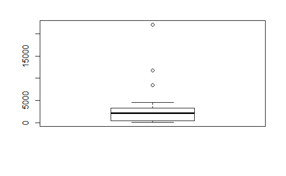

```r
# Create boxplot of gdp variable of demo
boxplot(demo$gdp)
```

## Import SPSS data with foreign (2)

In the previous exercise, you used the `to.data.frame` argument inside `read.spss()`. There are many other ways in which to customize the way your SPSS data is imported.

In this exercise you will experiment with another argument, `use.value.labels`. It specifies whether variables with value labels should be converted into R factors with levels that are named accordingly. The argument is `TRUE` by default which means that so called labelled variables inside SPSS are converted to factors inside R.

You’ll again be working with the international.sav data, which is available in your current working directory.

**INSTRUCTIONS**

Import the data file `"international.sav"` as a data frame, `demo_1`.

Print the first few rows of `demo_1` using the `head()` function.

Import the data file `"international.sav"` as a data frame, `demo_2`, but this time in a way such that variables with value labels are not converted to R factors.

Again, print the first few rows of `demo_2`. Can you tell the difference between the two data frames?

```r
# foreign is already loaded
# Import international.sav as demo_1
demo_1 <- read.spss("international.sav", to.data.frame = TRUE)
```

```
re-encoding from CP1252
```

```r
# Print out the head of demo_1
head(demo_1)
```

|  | id | country | contint | m_illit | f_illit | lifeexpt | gdp |
| --- | --- | --- | --- | --- | --- | --- | --- |
| 1 | 1 | Argentina | Americas | 3.0 | 3.0 | 16 | 3375 |
| 2 | 2 | Benin | Africa | 45.2 | 74.5 | 7 | 521 |
| 3 | 3 | Burundi | Africa | 33.2 | 48.1 | 5 | 86 |
| 4 | 4 | Chile | Americas | 4.2 | 4.4 | 14 | 4523 |
| 5 | 5 | Dominican Republic | Americas | 12.0 | 12.7 | 12 | 2408 |
| 6 | 6 | El Salvador | Americas | 17.6 | 22.9 | 11 | 2302 |

```r
# Import international.sav as demo_2
demo_2 <- read.spss("international.sav", to.data.frame = TRUE, use.value.labels = FALSE)
```

```
re-encoding from CP1252
```

```r
# Print out the head of demo_2
head(demo_2)
```

|  | id | country | contint | m_illit | f_illit | lifeexpt | gdp |
| --- | --- | --- | --- | --- | --- | --- | --- |
| 1 | 1 | Argentina | 2 | 3.0 | 3.0 | 16 | 3375 |
| 2 | 2 | Benin | 1 | 45.2 | 74.5 | 7 | 521 |
| 3 | 3 | Burundi | 1 | 33.2 | 48.1 | 5 | 86 |
| 4 | 4 | Chile | 2 | 4.2 | 4.4 | 14 | 4523 |
| 5 | 5 | Dominican Republic | 2 | 12.0 | 12.7 | 12 | 2408 |
| 6 | 6 | El Salvador | 2 | 17.6 | 22.9 | 11 | 2302 |